# NP AMR analyses

## Summarise single isolate epidemiology

### Generate microreact output files

```r
write.table(Mcat_microreact_df %>%
              dplyr::mutate(id = paste0(id,"_fa")),
            file = "./microreact_analysis/Mcat_microreact.csv",
            sep = ",",
            col.names = TRUE,
            row.names = FALSE,
            quote = FALSE)

write.table(Hflu_microreact_df %>%
              dplyr::mutate(id = paste0(id,"_fa")),
            file = "./microreact_analysis/Hflu_microreact.csv",
            sep = ",",
            col.names = TRUE,
            row.names = FALSE,
            quote = FALSE)
```

Microreact visualisations are available from:

- *M. catarrhalis*: https://microreact.org/project/hQ9WcBim9Yspg9vEvVPWqr-moraxella-population-structure
- Serosensitive *M. catarrhalis*: https://microreact.org/project/gdU9T8EZNCXgQttppvuCVw-serosensitive-moraxella-poppunk
- Seroresistance *M. catarrhalis*: https://microreact.org/project/cYSZ1g2Scstfbg1hVpoe7r-seroresistant-moraxella-poppunk
- *H. influenzae*: https://microreact.org/project/qCSg4Ut9QYfAXo3tK3gTDu-h-influenzae-poppunk

## Compare strain frequencies between locations

### Plot distributions of strain frequencies across locations

### Compare *H. influenzae* strain frequencies between locations

TO DO

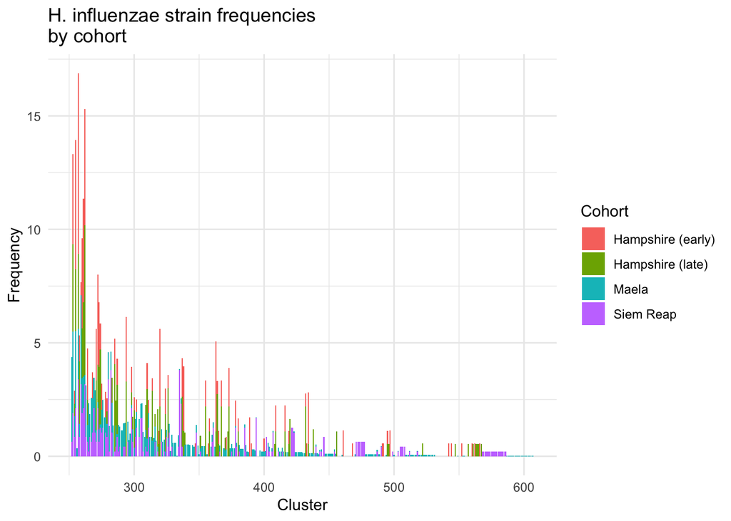

```r
Hflu_strains <- Hflu_microreact_df %>%
  group_by(id,
           Cohort,
           Cluster) %>%
  summarise(strains_count = n_distinct(id),
            .groups = "drop") %>%
  arrange(Cohort)

Hflu_strains_freq <- Hflu_strains %>%
  group_by(Cohort) %>%
  mutate(Frequency = (strains_count / sum(strains_count) *100))

ggplot(Hflu_strains_freq,
       aes(x = Cluster,
           y = Frequency,
           fill = Cohort)) +
  geom_bar(stat = "identity",
           position = "stack") +
  theme_minimal() +
  labs(title = "H. influenzae strain frequencies\nby cohort",
       x = "Cluster",
       y = "Frequency",
       fill = "Cohort")
```

### Compare strain frequencies between locations

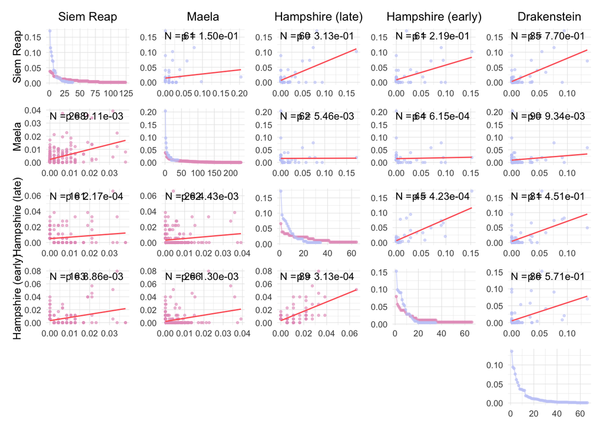

```r
p <- plot_mcat_cluster_pairs_two_species(
  dplyr::bind_rows(
    process_strain_frequencies(Mcat_microreact_df) %>%
      dplyr::mutate(Species = "Moraxella catarrhalis"),
    process_strain_frequencies(Hflu_microreact_df) %>%
      dplyr::mutate(Species = "Haemophilus influenzae")
  ),
  species1 = "Moraxella catarrhalis",
  species2 = "Haemophilus influenzae",
  species_palette = species_palette,
  drakenstein_name = "Drakenstein"
)

p
```

## Compare gene frequencies across locations

After we got the gene presence absence from *Moraxella catarrhalis* Panaroo, then we extracted that csv file for doing tidy column, calculate the gene frequencies and number of genomes then final plotting scatter graph and plot histograms between countries.

### Parse Panaroo output

This analysis used Panaroo version 1.5.2.

```bash
mkdir -p Haemophilus_panaroo_results
panaroo-qc -t 8 --graph_type all -i *.gff --ref_db refseq.genomes.k21s1000.msh -o results
panaroo -i *.gff -o Haemophilus_panaroo_results --clean-mode moderate --merge_paralogs --remove-invalid-genes
```

Read in the gene presence/absence matrix for *H. influenzae*:

```r
hflu_tar <- "./panaroo_output/Hflu_gene_presence_absence.tar.gz"

# if (identical(Sys.getenv("CI"), "true")) {
#   hflu_tar <- "./panaroo_output/test.Hflu_gene_presence_absence.tar.gz"
# }

tmp_dir  <- tempdir()
hflu_fn <- "Hflu_gene_presence_absence.csv"
tmp_path <- file.path(tmp_dir, hflu_fn)

archive::archive_extract(
  hflu_tar,
  file = hflu_fn,
  dir  = tmp_dir
)

Hinflu_gene_preabsence <-
  read.csv(
    tmp_path,
    header = TRUE,
    comment.char = "",
    check.names = FALSE,
    sep = ","
    ) %>%
    tidyr::pivot_longer(
      cols = -c(
      Gene,
      `Non-unique Gene name`,
      Annotation
      ),
      names_to = "npg_run_id",
      values_to = "CDS"
    )

included_hflu <- unique(Hinflu_gene_preabsence$npg_run_id)

if (length(setdiff(expected_hflu,included_hflu)) > 0 | length(setdiff(included_hflu,expected_hflu)) > 0) {
  stop("Hflu Panaroo not run on correct isolate set")
}
```

### Pangenome curve for *H. influenzae*

TO DO

```r
if (identical(Sys.getenv("CI"), "true")) {

  message("CI environment detected: memory management commands")
  Hinflu_gene_preabsence %<>%
  slice_sample(prop = 0.01)

}
```

### Analysis of *M. catarrhalis* gene content

```bash
mkdir -p Moraxella_panaroo_result
panaroo-qc -t 8 --graph_type all -i *.gff --ref_db refseq.genomes.k21s1000.msh -o results
panaroo -i *.gff -o Moraxella_panaroo_result --clean-mode moderate --merge_paralogs --remove-invalid-genes
```

Read in the gene presence/absence matrix:

```r
mcat_tar <- "./panaroo_output/Mcat_gene_presence_absence.tar.gz"

# if (identical(Sys.getenv("CI"), "true")) {
#   mcat_tar <- "./panaroo_output/test.Mcat_gene_presence_absence.tar.gz"
# }

tmp_dir  <- tempdir()
mcat_fn <- "Mcat_gene_presence_absence.csv"
tmp_path <- file.path(tmp_dir, mcat_fn)

archive::archive_extract(
  mcat_tar,
  file = mcat_fn,
  dir  = tmp_dir
)
```

```r
Mcat_gene_preabsence <- read.csv(
  tmp_path,
  header = TRUE,
  comment.char = "",
  check.names = FALSE,
  sep = ","
  ) %>%
  tidyr::pivot_longer(
    cols = -c(
      Gene,
      `Non-unique Gene name`,
      Annotation
      ),
    names_to = "npg_run_id",
    values_to = "CDS"
  )

included_mcat <- unique(Mcat_gene_preabsence$npg_run_id)

if (length(setdiff(expected_mcat,included_mcat)) > 0 | length(setdiff(included_mcat,expected_mcat)) > 0) {
  stop("Mcat Panaroo not run on correct isolate set")
}
```

### Pangenome curve for *M. catarrhalis*

TO DO

```r
if (identical(Sys.getenv("CI"), "true")) {

  message("CI environment detected: downsampling Hinflu_long_filtered for speed/memory.")
  Mcat_gene_preabsence %<>%
  slice_sample(prop = 0.01)

}
```

### Geographic analysis of gene frequencies

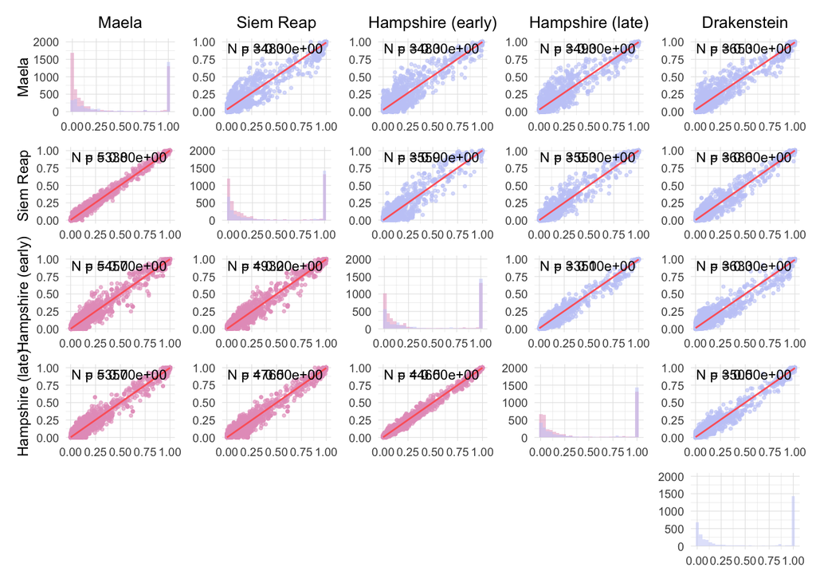

```r
p <- plot_mcat_cluster_pairs_two_species(
  dplyr::bind_rows(
    Mcat_gene_preabsence %>%
      process_gene_frequencies(Mcat_microreact_df)  %>%
      dplyr::mutate(Species = "Moraxella catarrhalis"),
    Hinflu_gene_preabsence %>%
      process_gene_frequencies(Hflu_microreact_df)  %>%
      dplyr::mutate(Species = "Haemophilus influenzae")
  ),
  species1 = "Moraxella catarrhalis",
  species2 = "Haemophilus influenzae",
  species_palette = species_palette,
  drakenstein_name = "Drakenstein",
  hist_on_diagonal = TRUE
)

p
```

## Compare gene frequencies across locations

### Frequency of plasmids across populations

### Frequency of plasmid-borne genes across populations

## Phylogenetic analysis

TO DO: Gubbins

### Analysis of recombination across populations

TO DO: fastGEAR

# Analysis of long-read data

## Accessing long-read data

```bash
# Set up environment
module load PaM/environment
module load ISG/IRODS/1.0
kinit
iinit

iget -r /seq/ont/promethion/offline-deplexes/PC24B148/ONTRUN-196/TRAC-2-7738/20240219_1036_3A_PAU55810_bf5bbe22/dorado/7.1.4/sup/simplex/modified/5hmc_5mc_cg/
iget -r /seq/ont/promethion/offline-deplexes/PC24B148/ONTRUN-196/TRAC-2-7739/20240219_1036_3C_PAU55034_a15a64d8/dorado/7.1.4/sup/simplex/modified/5hmc_5mc_cg/

for INDEX in {01..96}; do mkdir -p barcode${INDEX}; for C in $(ls -d ./5hmc_5mc_cg/default/chunka[abcdefghi]); do CHUNK=`basename $C`; for FILE in  ./5hmc_5mc_cg/default/$CHUNK/barcode${INDEX}/*; do BASENAME=`basename ${FILE}`; mv ${FILE} ./barcode${INDEX}/${CHUNK}_${BASENAME}; done; done; done
```

## Assembling long-read data

```bash
declare -i N; N=1; for f in $(ls -d barcode*); do echo -en "cd /data/pam/team284/nc3/scratch/NP_AMR/data/nanopore_data/run_1/$f\nmodule load flye/2.9.2--py310h590eda1_0\nflye -t 4 --genome-size 2.0m --nano-hq *fastq.gz --out-dir ${f}_rr_out\n" > flye_job.$N; chmod +x ./flye_job.$N; N=($N+1); done
bsub -n 4 -M 16000 -R 'select[mem>16000] rusage[mem=16000] span[hosts=1]' -o run_1_flye.%I.rerun.o -e run_1_flye.%I.rerun.e -J flye_job[1-96] ./flye_job.\${LSB_JOBINDEX}

declare -i N; N=1; for f in $(ls -d barcode*); do echo -en "cd /data/pam/team284/nc3/scratch/NP_AMR/data/nanopore_data/run_2/$f\nmodule load flye/2.9.2--py310h590eda1_0\nflye -t 4 --genome-size 2.0m --nano-hq *fastq.gz --out-dir ${f}_rr_out\n" > flye_job.$N; chmod +x ./flye_job.$N; N=($N+1); done
bsub -n 4 -M 16000 -R 'select[mem>16000] rusage[mem=16000] span[hosts=1]' -o run_2_flye.%I.rerun.o -e run_2_flye.%I.rerun.e -J flye_job_2[1-96] ./flye_job.\${LSB_JOBINDEX}
```

## Long-read sequencing of representative isolates

These were chosen as:

- Representing the clusters with >9 isolates
- Plus representing any multidrug-resistance profiles not seen in the representatives of the most common clusters
- Only a subset were available for reculturing

```r
long_read_sample_df <-
  read.csv("sample_data/long_read_sequence_data.csv")
```

## Methylation analyses from long-read data

Is the sharing of plasmids between species limited by RMS?

Methylase: group_2030.

## Passage analysis from long-read data

Also a passage was run of four isolates. Each was started from a single colony on THY. Each was grown for 24 h in 10 mL Mix media. Successive inoculations used 100 uL. Four colonies were picked from each day from THY plates.

# Analysis of deep sequencing data

```r
# Information on antibiotic treatment
treatment_df <-
  read.csv("./sample_data/Pneumo-DEEP_illness_abx_summary.csv") %>%
    dplyr::mutate(date_start = lubridate::as_date(date_start, format = "%m/%d/%y"))

# Information on swabs
infant_swabs_df <-
  dplyr::bind_rows(
    read.csv("./sample_data/Maela_infant_swabs.csv") %>%
      dplyr::mutate(specdate = lubridate::as_date(specdate, format = "%d/%m/%Y")) %>%
      dplyr::select(study_code,specnum,specdate,acute) %>%
      dplyr::rename(codenum = study_code) %>%
      dplyr::mutate(acute = dplyr::if_else(acute == 0,"No","Yes")),
    read.csv("./sample_data/20151026_maela_imm_who_data.csv") %>%
      dplyr::mutate(specdate = lubridate::as_date(specdate, format = "%d/%m/%Y")) %>%
      dplyr::select(codenum,category,dob,specdate,specnum,acute),
    read.csv("./sample_data/pneumoDEEP_microreact_info.csv") %>%
      dplyr::mutate(specdate = lubridate::as_date(specdate, format = "%d/%m/%Y")) %>%
      dplyr::select(codenum,category,dob,specdate,specnum,acute)
  ) %>%
    dplyr::distinct() %>%
    dplyr::group_by(codenum) %>%
    tidyr::fill(category,
                dob,.direction = "updown")
# For each specimen, find previous treatment
previous_treatment_df <-
  infant_swabs_df %>%
    left_join(treatment_df, by = "codenum", relationship = "many-to-many") %>%
    filter(specdate >= date_start) %>%
    group_by(specnum) %>%
    arrange(desc(date_start)) %>%
    slice(1) %>%
    mutate(days_since_previous = as.numeric(specdate - date_start)) %>%
    select(specnum, days_since_previous,
           previous_treatment_date = date_start,
           previous_drug1 = drug1, previous_drug2 = drug2)

# For each specimen, find next treatment
next_treatment_df <-
  infant_swabs_df %>%
    left_join(treatment_df, by = "codenum", relationship = "many-to-many") %>%
    filter(specdate <= date_start) %>%
    group_by(specnum) %>%
    arrange(date_start) %>%
    slice(1) %>%
    mutate(days_until_next = as.numeric(date_start - specdate)) %>%
    select(specnum, days_until_next,
           next_treatment_date = date_start,
           next_drug1 = drug1, next_drug2 = drug2)

# Combine all information
treatment_sampling_df <-
  infant_swabs_df %>%
    left_join(previous_treatment_df, by = "specnum") %>%
    left_join(next_treatment_df, by = "specnum") %>%
    dplyr::right_join(
      sample_df %>%
        dplyr::filter(Species == "Mixed bacteria" & Country == "Thailand") %>%
        dplyr::select(npg_run_id,Isolate,sample_donor_id,sample_supplier_name) %>%
        dplyr::mutate(specnum = gsub("_Mixed","",Isolate)),
      by = "specnum"
    )
```

## Co-colonisation analysis of species

- Which species co-exist, and which compete, based on the observed deep sequencing data?
- Do seroresistant and serosensitive Moraxellae appear to compete?
- Are these patterns consistent across countries?
- Is there variation with age in Maela? (mother v. infant, changes in first year)
- Is there variation in acute/non-acute in Maela?

## Co-colonisation analysis of strains

- Is the same pattern of co-colonisation observed across species (including serosensitive/seroresistant Moraxellae)?
- Seroresistant/serosensitive difference in acute in Maela?
- Is the same level of co-colonisation observed across countries?
- Removal of prophage sequences - does this improve assignment to strains?
- Are long-read references better than short-read references?

## Timing of antibiotic administration and species presence

- Are different species enriched after antibiotic administration in Maela?
- Is there less co-colonisation between strains after antibiotic administration?